# Exercises — Chapter 4 (4.23–4.41)

The Multivariate Normal Distribution

Johnson & Wichern — *Applied Multivariate Statistical Analysis

## Exercise 4.23

Use these 10 observations to complete the following.

1. Construct a $Q$–$Q$ plot. Do the data seem to be normally distributed? Explain.

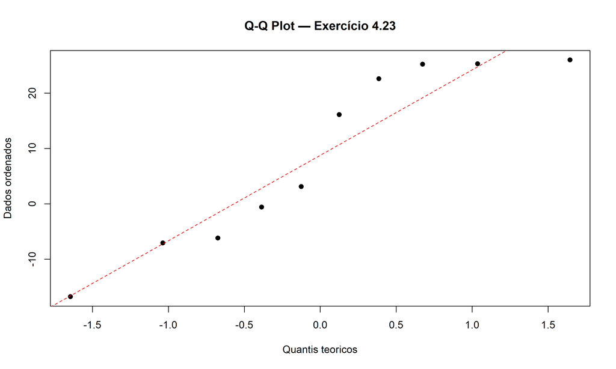

```r
x <- c(26.0, 22.6, 16.1, 25.2, -6.2, -7.1, -16.8, 25.3, 3.1, -0.6)
n <- length(x)

# (a) Q-Q plot
x_ord <- sort(x)
q <- qnorm(((1:n) - 0.5) / n)
plot(q, x_ord, pch = 19, xlab = "Quantis teoricos", ylab = "Dados ordenados",
     main = "Q-Q Plot — Exercício 4.23")
abline(lm(x_ord ~ q), col = "red", lty = 2)
```

2. Carry out a test of normality based on the correlation coefficient $r_Q$. [See (4-31).] Let the significance level be $\alpha = .10$.

```r
# (b) Teste r_Q com alpha = 0.10
r_Q <- cor(q, x_ord)
cat("r_Q =", round(r_Q, 4), "\n")
```

```
## r_Q = 0.947
```

```r
cat("r_crit (n=10, α=0.10) = 0.9351\n")
```

```
## r_crit (n=10, α=0.10) = 0.9351
```

```r
cat(if (r_Q >= 0.9351) "Não rejeitamos H0: normalidade.\n" else "Rejeitamos H0.\n")
```

```
## Não rejeitamos H0: normalidade.
```

```r
#Usando funcao pronta
sf.test(x)
```

```
##
##  Shapiro-Francia normality test
##
## data:  x
## W = 0.90262, p-value = 0.1979
```

## Exercise 4.24

Exercise 1.4 contains data on three variables for the world’s 10 largest companies as of April 2005. For the sales ($x_1$) and profits ($x_2$) data:

1. Construct $Q$–$Q$ plots. Do these data appear to be normally distributed? Explain.

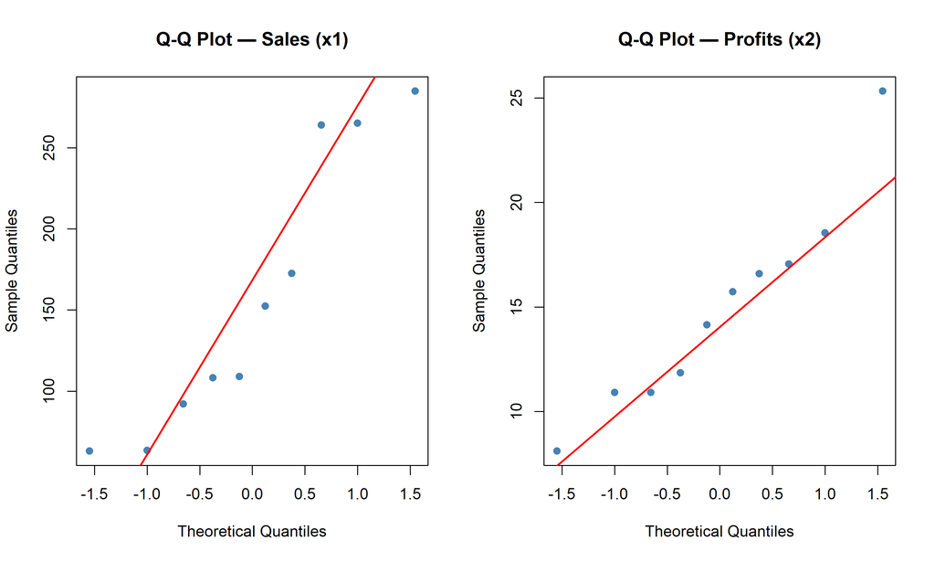

```r
x1 <- c(108.28, 152.36, 108.91, 63.32, 62.97, 263.99, 265.19, 285.06, 92.01, 172.62)
x2 <- c(17.05, 16.59, 10.91, 14.14, 11.84, 25.33, 18.54, 15.73, 8.10, 10.91)

par(mfrow = c(1, 2))

qqnorm(x1, main = "Q-Q Plot — Sales (x1)", pch = 19, col = "steelblue")
qqline(x1, col = "red", lwd = 2)

qqnorm(x2, main = "Q-Q Plot — Profits (x2)", pch = 19, col = "steelblue")
qqline(x2, col = "red", lwd = 2)
```

2. Carry out a test of normality based on the correlation coefficient $r_Q$. [See (4-31).] Set the significance level at $\alpha = .10$. Do the results of these tests corroborate the results in Part a?

```r
sf.test(x1)
```

```
##
##  Shapiro-Francia normality test
##
## data:  x1
## W = 0.89577, p-value = 0.1667
```

```r
sf.test(x2)
```

```
##
##  Shapiro-Francia normality test
##
## data:  x2
## W = 0.93459, p-value = 0.4375
```

## Exercise 4.25

Refer to the data for the world’s 10 largest companies in Exercise 1.4. Construct a chi-square plot using all three variables. The chi-square quantiles are

$$0.3518, \; 0.7978, \; 1.2125, \; 1.6416,
\; 2.1095, \; 2.6430, \; 3.2831, \; 4.1083, \; 5.3170, \;
7.8147$$

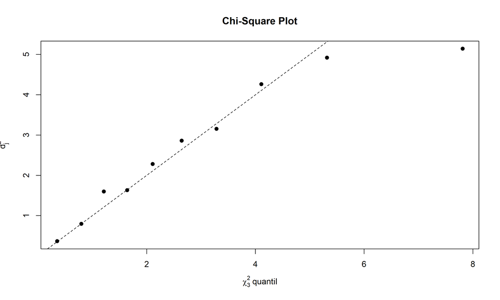

```r
X <- matrix(c(
  108.28, 17.05, 1484.10,
  152.36, 16.59,  750.33,
  108.91, 10.91,  801.00,
   65.45, 14.14, 1110.46,
   62.97,  9.52, 1031.29,
  263.99, 25.33,  195.26,
  265.19, 18.54,  193.83,
  285.06, 15.73,  191.11,
   92.01,  8.10, 1175.16,
  172.62, 10.91,  233.72
), ncol = 3, byrow = TRUE)

# Distâncias de Mahalanobis
d2 <- mahalanobis(X, colMeans(X), cov(X))

# Quantis qui-quadrado fornecidos (p = 3, n = 10)
q_chi <- c(0.3518, 0.7978, 1.2125, 1.6416, 2.1095,
           2.6430, 3.2831, 4.1083, 5.3170, 7.8147)

# Chi-square plot
plot(q_chi, sort(d2),
     xlab = expression(chi[3]^2 ~ "quantil"),
     ylab = expression(d[j]^2),
     main = "Chi-Square Plot",
     pch = 19)
abline(0, 1, lty = 2)
```

## Exercise 4.26

Exercise 1.2 gives the age $x_1$, measured in years, as well as the selling price $x_2$, measured in thousands of dollars, for $n = 10$ used cars. These data are reproduced as follows:

| $x_1$ | 1 | 2 | 3 | 3 | 4 | 5 | 6 | 8 | 9 | 11 |
| --- | --- | --- | --- | --- | --- | --- | --- | --- | --- | --- |
| $x_2$ | 18.95 | 19.00 | 17.95 | 15.54 | 14.00 | 12.95 | 8.94 | 7.49 | 6.00 | 3.99 |

1. Use the results of Exercise 1.2 to calculate the squared statistical distances $(\mathbf{x}_j - \bar{\mathbf{x}})'\mathbf{S}^{-1}(\mathbf{x}_j - \bar{\mathbf{x}})$, $j = 1, 2, \ldots, 10$, where $\mathbf{x}_j' = [x_{j1}, x_{j2}]$.

```r
# Dados
x1 <- c(1, 2, 3, 3, 4, 5, 6, 8, 9, 11)
x2 <- c(18.95, 19.00, 17.95, 15.54, 14.00, 12.95, 8.94, 7.49, 6.00, 3.99)
X <- cbind(x1, x2)
n <- nrow(X)

# (a) Distâncias de Mahalanobis ao quadrado
d2 <- mahalanobis(X, colMeans(X), cov(X))
round(d2, 4)
```

```
##  [1] 1.8753 2.0203 2.9009 0.7353 0.3105 0.0176 3.7329 0.8165 1.3753 4.2153
```

2. Using the distances in Part a, determine the proportion of the observations falling within the estimated 50% probability contour of a bivariate normal distribution.

```r
# (b) Proporção dentro do contorno de 50%
# Sob normalidade bivariada, o contorno de 50% corresponde a chi²(2, 0.50)
corte <- qchisq(0.50, df = 2)
cat("Proporção dentro do contorno 50%:", mean(d2 <= corte), "\n")
```

```
## Proporção dentro do contorno 50%: 0.5
```

3. Order the distances in Part a and construct a chi-square plot.

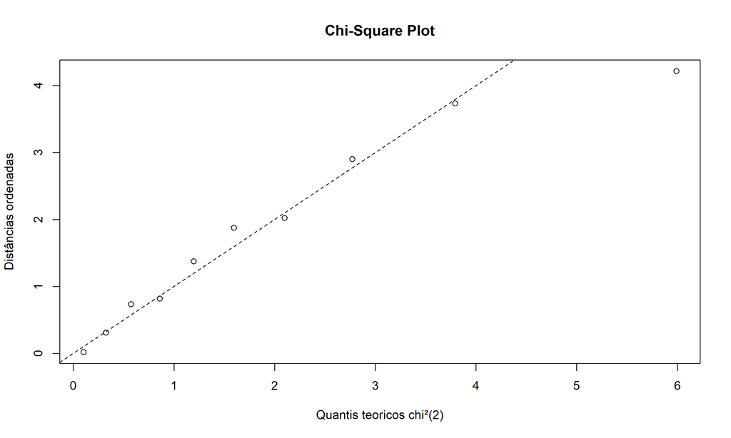

```r
# (c) Chi-square plot
d2_ord <- sort(d2)
q_teoricos <- qchisq((1:n - 0.5) / n, df = 2)
plot(q_teoricos, d2_ord,
     xlab = "Quantis teoricos chi²(2)",
     ylab = "Distâncias ordenadas",
     main = "Chi-Square Plot")
abline(0, 1, lty = 2)
```

4. Given the results in Parts b and c, are these data approximately bivariate normal? Explain.

```r
# (d) Correlação do Q-Q plot como indicador de normalidade
cat("Correlação rQ:", cor(q_teoricos, d2_ord), "\n")
```

```
## Correlação rQ: 0.9636795
```

## Exercise 4.27

Consider the radiation data (with door closed) in Example 4.10. Construct a $Q$–$Q$ plot for the natural logarithms of these data. [Note that the natural logarithm transformation corresponds to the value $\lambda = 0$ in (4-34).] Do the natural logarithms appear to be normally distributed? Compare your results with Figure 4.13. Does the choice $\lambda = \tfrac{1}{4}$ or $\lambda = 0$ make much difference in this case?

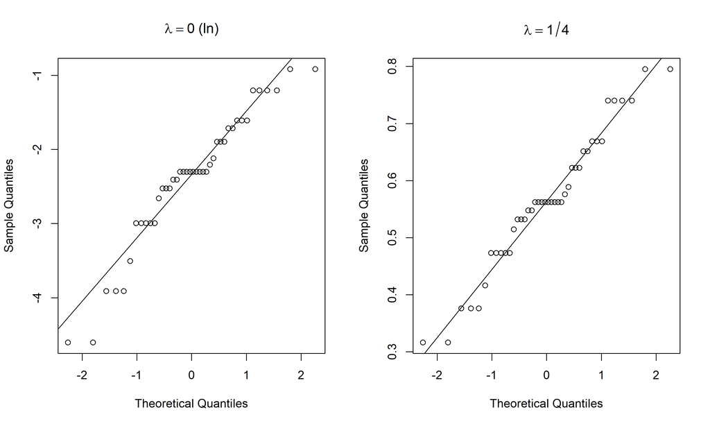

```r
# Dados de radiação (porta fechada) - Table 4.1, n = 42
x <- c(0.15, 0.09, 0.18, 0.10, 0.05, 0.12, 0.08, 0.05, 0.08, 0.10,
       0.07, 0.02, 0.01, 0.10, 0.10, 0.10, 0.02, 0.10, 0.01, 0.40,
       0.10, 0.05, 0.03, 0.05, 0.15, 0.10, 0.15, 0.09, 0.08, 0.18,
       0.10, 0.20, 0.11, 0.30, 0.02, 0.20, 0.20, 0.30, 0.30, 0.40,
       0.30, 0.05)

# Transformações
ln_x <- log(x)          # λ = 0
x_14 <- x^(1/4)         # λ = 1/4

# Q-Q plots lado a lado
par(mfrow = c(1, 2))
qqnorm(ln_x, main = expression(lambda == 0 ~ "(ln)"))
qqline(ln_x)
qqnorm(x_14, main = expression(lambda == 1/4))
qqline(x_14)
```

```r
# Testes de normalidade
shapiro.test(ln_x)
```

```
##
##  Shapiro-Wilk normality test
##
## data:  ln_x
## W = 0.93878, p-value = 0.02591
```

```r
shapiro.test(x_14)
```

```
##
##  Shapiro-Wilk normality test
##
## data:  x_14
## W = 0.96481, p-value = 0.2188
```

*The following exercises may require a computer.*

## Exercise 4.28

Consider the air-pollution data given in Table 1.5. Construct a $Q$–$Q$ plot for the solar radiation measurements and carry out a test for normality based on the correlation coefficient $r_Q$ [see (4-31)]. Let $\alpha = .05$ and use the entry corresponding to $n = 40$ in Table 4.2.

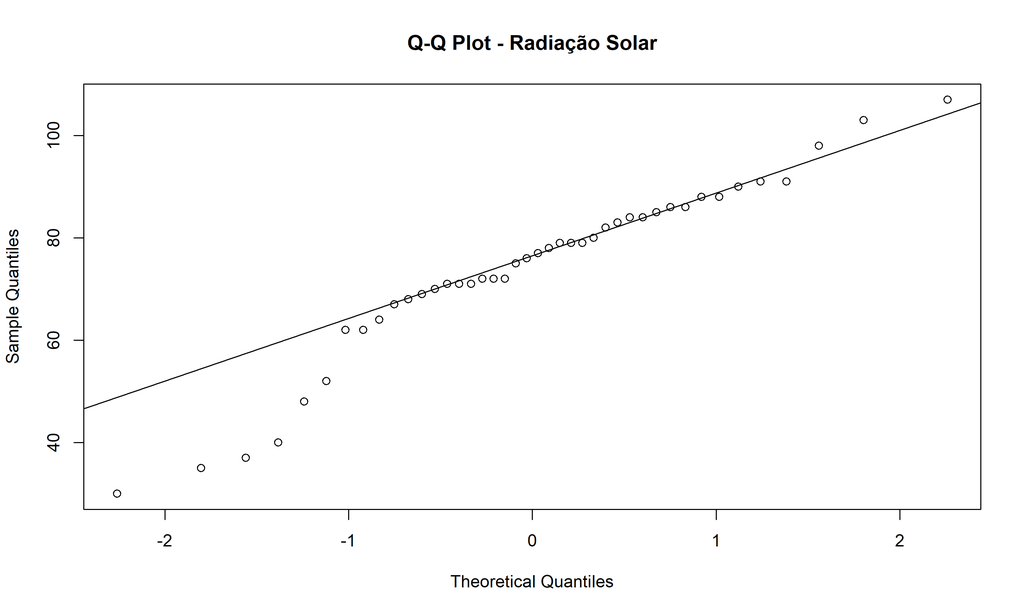

```r
# Dados de radiação solar (x2) da Tabela 1.5
x2 <- c(98, 107, 103, 88, 91, 90, 84, 72, 82, 64,
         71, 91, 72, 70, 72, 77, 76, 71, 67, 69,
         62, 88, 80, 30, 83, 84, 78, 79, 62, 37,
         71, 52, 48, 75, 35, 85, 86, 86, 79, 79,
         68, 40)

n <- length(x2)

# (a) Q-Q plot
qqnorm(x2, main = "Q-Q Plot - Radiação Solar")
qqline(x2)
```

```r
# (b) Teste de normalidade via correlação rQ
x_ord <- sort(x2)
q_j <- qnorm((1:n - 0.5) / n)
r_Q <- cor(x_ord, q_j)

cat("n =", n, "\n")
```

```
## n = 42
```

```r
cat("r_Q =", round(r_Q, 4), "\n")
```

```
## r_Q = 0.9693
```

```r
# Valor crítico da Tabela 4.2: para n = 40, alpha = 0.05 -> r_Q critico ~ 0.9726
r_crit <- 0.9726
cat("Valor crítico (n=40, alpha=0.05) =", r_crit, "\n")
```

```
## Valor crítico (n=40, alpha=0.05) = 0.9726
```

```r
if (r_Q < r_crit) {
  cat("Conclusão: r_Q < r_crit => Rejeita H0. Dados NÃO parecem normais.\n")
} else {
  cat("Conclusão: r_Q >= r_crit => Não rejeita H0. Dados parecem normais.\n")
}
```

```
## Conclusão: r_Q < r_crit => Rejeita H0. Dados NÃO parecem normais.
```

## Exercise 4.29

Given the air-pollution data in Table 1.5, examine the pairs $X_5 = \text{NO}_2$ and $X_6 = \text{O}_3$ for bivariate normality.

1. Calculate statistical distances $(\mathbf{x}_j - \bar{\mathbf{x}})'\mathbf{S}^{-1}(\mathbf{x}_j - \bar{\mathbf{x}})$, $j = 1, 2, \ldots, 42$, where $\mathbf{x}_j' = [x_{j5}, x_{j6}]$.

```r
# Dados da Tabela 1.5 - Air Pollution (Johnson & Wichern)
# Colunas: Solar, Wind, Radiation, CO, NO, NO2, O3, HC
dados <- read.table(text = "
8 98 7 2 12 8 2
7 107 4 3 9 5 3
7 103 4 3 5 6 3
10 88 5 2 8 15 4
6 91 4 2 8 10 3
8 90 5 2 12 12 4
9 84 7 4 12 15 5
5 72 6 4 21 14 4
7 82 5 1 11 11 3
8 64 5 2 13 9 4
6 71 5 4 10 3 3
6 91 4 2 12 7 3
7 72 7 4 18 10 3
10 70 4 2 11 7 3
10 72 4 1 8 10 3
9 77 4 1 9 10 3
8 76 4 1 7 7 3
8 71 5 3 16 4 4
9 67 4 2 13 2 3
9 69 3 3 9 5 3
10 62 5 3 14 4 4
9 88 4 2 7 6 3
8 80 4 2 13 11 4
5 30 3 3 5 2 3
6 83 5 1 10 23 4
8 84 3 2 7 6 3
6 78 4 2 11 11 3
8 79 2 1 7 10 3
6 62 4 3 9 8 3
10 37 3 1 7 2 3
8 71 4 1 10 7 3
7 52 4 1 12 8 4
5 48 6 5 8 4 3
6 75 4 1 10 24 3
10 35 4 1 6 9 2
8 85 4 1 9 10 2
5 86 3 1 6 12 2
5 86 7 2 13 18 2
7 79 7 4 9 25 3
7 79 5 2 8 6 2
6 68 6 2 11 14 3
8 40 4 3 6 5 2
", header = FALSE)

colnames(dados) <- c("Wind", "SolarRad", "CO", "NO", "NO2", "O3", "HC")
X <- dados[, c("NO2", "O3")]

n <- nrow(X)

# (a) Distâncias estatísticas
xbar <- colMeans(X)
S <- cov(X)
d2 <- mahalanobis(X, xbar, S)
cat("(a) Distâncias estatísticas (d²):\n")
```

```
## (a) Distâncias estatísticas (d²):
```

```r
print(round(d2, 4))
```

```
##  [1]  0.4607  0.6592  2.3771  1.6283  0.4135  0.4761  1.1849 10.6392  0.1388
## [10]  0.8162  1.3566  0.6228  5.6494  0.3159  0.4135  0.1225  0.8988  4.7647
## [19]  3.0089  0.6592  2.7741  1.0360  0.7874  3.4438  6.1489  1.0360  0.1388
## [28]  0.8856  0.1380  2.2489  0.1901  0.4607  1.1472  7.0857  1.4584  0.1225
## [37]  1.8985  2.7783  8.4731  0.6370  0.7032  1.8014
```

2. Determine the proportion of observations $\mathbf{x}_j' = [x_{j5}, x_{j6}]$, $j = 1, 2, \ldots, 42$, falling within the approximate 50% probability contour of a bivariate normal distribution.

```r
# (b) Proporção dentro do contorno de 50%
# Sob normalidade bivariada, d² ~ chi²(2); quantil 50% = qchisq(0.5, 2)
corte_50 <- qchisq(0.5, 2)
prop <- mean(d2 <= corte_50)
cat("\n(b) Quantil chi²(2) a 50%:", round(corte_50, 4), "\n")
```

```
##
## (b) Quantil chi²(2) a 50%: 1.3863
```

```r
cat("Proporção observada dentro do contorno de 50%:", prop, "\n")
```

```
## Proporção observada dentro do contorno de 50%: 0.6190476
```

3. Construct a chi-square plot of the ordered distances in Part a.

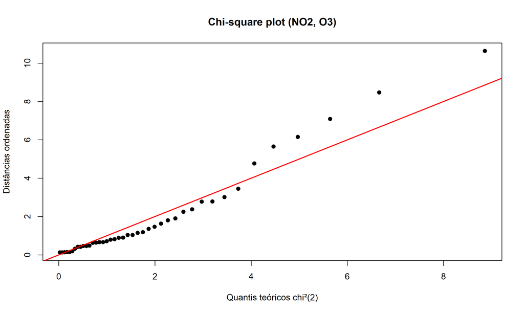

```r
# (c) Gráfico chi-quadrado
d2_ord <- sort(d2)
p <- ((1:n) - 0.5) / n
q_teoricos <- qchisq(p, df = 2)

plot(q_teoricos, d2_ord,
     xlab = "Quantis teóricos chi²(2)",
     ylab = "Distâncias ordenadas",
     main = "Chi-square plot (NO2, O3)",
     pch = 19)
abline(0, 1, col = "red", lwd = 2)
```

## Exercise 4.30

Consider the used-car data in Exercise 4.26.

1. Determine the power transformation $\hat{\lambda}_1$ that makes the $x_1$ values approximately normal. Construct a $Q$–$Q$ plot for the transformed data.

```r
x1 <- c(1, 2, 3, 3, 4, 5, 6, 8, 9, 11)
x2 <- c(18.95, 19.00, 17.95, 15.54, 14.00, 12.95, 8.94, 7.49, 6.00, 3.99)
dados <- data.frame(x1, x2)

cat("=== (a) Transformação Box-Cox para x1 ===\n")
```

```
## === (a) Transformação Box-Cox para x1 ===
```

```r
bc1 <- powerTransform(x1)
(lambda1 <- bc1$roundlam)
```

```
## x1
##  1
```

```r
summary(bc1)
```

```
## bcPower Transformation to Normality
##    Est Power Rounded Pwr Wald Lwr Bnd Wald Upr Bnd
## x1    0.3709           1      -0.5462       1.2879
##
## Likelihood ratio test that transformation parameter is equal to 0
##  (log transformation)
##                             LRT df    pval
## LR test, lambda = (0) 0.6604358  1 0.41641
##
## Likelihood ratio test that no transformation is needed
##                            LRT df    pval
## LR test, lambda = (1) 1.625408  1 0.20234
```

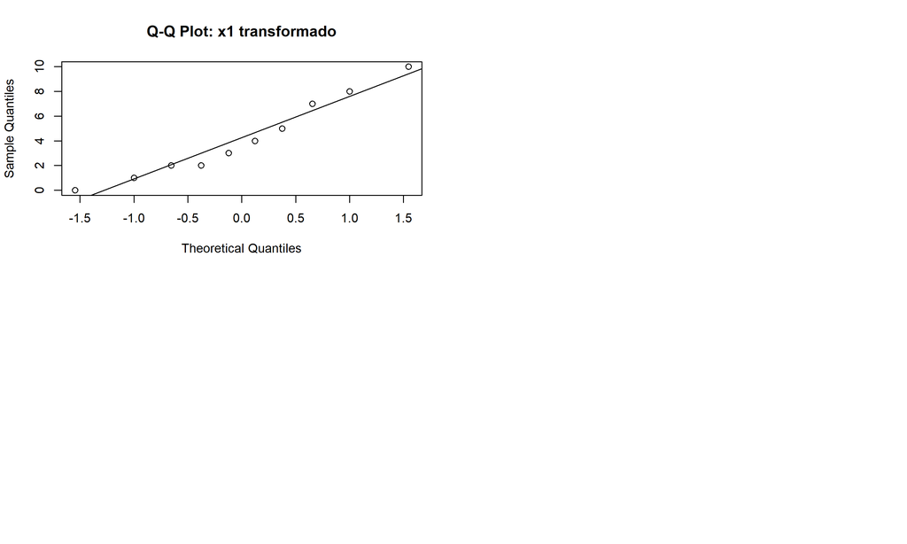

```r
# Q-Q plot dos dados transformados
x1_trans <- bcPower(x1, bc1$roundlam)
par(mfrow = c(2, 2))
qqnorm(x1_trans, main = "Q-Q Plot: x1 transformado"); qqline(x1_trans)
```

2. Determine the power transformation $\hat{\lambda}_2$ that makes the $x_2$ values approximately normal. Construct a $Q$–$Q$ plot for the transformed data.

```r
cat("\n=== (b) Transformação Box-Cox para x2 ===\n")
```

```
##
## === (b) Transformação Box-Cox para x2 ===
```

```r
bc2 <- powerTransform(x2)
(lambda2 <- bc2$roundlam)
```

```
## x2
##  1
```

```r
summary(bc2)
```

```
## bcPower Transformation to Normality
##    Est Power Rounded Pwr Wald Lwr Bnd Wald Upr Bnd
## x2    0.9362           1      -0.5933       2.4657
##
## Likelihood ratio test that transformation parameter is equal to 0
##  (log transformation)
##                           LRT df    pval
## LR test, lambda = (0) 1.58137  1 0.20856
##
## Likelihood ratio test that no transformation is needed
##                               LRT df    pval
## LR test, lambda = (1) 0.006638004  1 0.93507
```

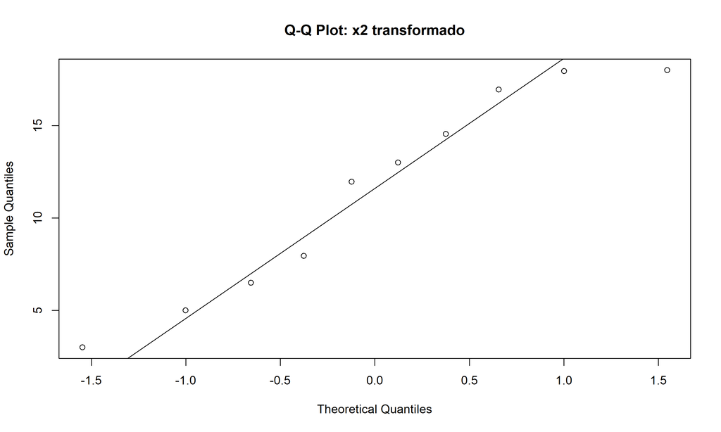

```r
x2_trans <- bcPower(x2, bc2$roundlam)
qqnorm(x2_trans, main = "Q-Q Plot: x2 transformado"); qqline(x2_trans)
```

3. Determine the power transformations $\hat{\boldsymbol{\lambda}}' = [\hat{\lambda}_1, \hat{\lambda}_2]$ that make the $\{x_1, x_2\}$ values jointly normal using (4-40). Compare the results with those obtained in Parts a and b.

```r
cat("\n=== (c) Transformação Box-Cox multivariada ===\n")
```

```
##
## === (c) Transformação Box-Cox multivariada ===
```

```r
bc_multi <- powerTransform(cbind(x1, x2))
(lambdas <- bc_multi$roundlam)
```

```
## x1 x2
##  1  0
```

```r
summary(bc_multi)
```

```
## bcPower Transformations to Multinormality
##    Est Power Rounded Pwr Wald Lwr Bnd Wald Upr Bnd
## x1    1.2732           1       0.6707       1.8758
## x2    0.0310           0      -0.7008       0.7629
##
## Likelihood ratio test that transformation parameters are equal to 0
##  (all log transformations)
##                              LRT df      pval
## LR test, lambda = (0 0) 21.93775  2 1.723e-05
##
## Likelihood ratio test that no transformations are needed
##                              LRT df     pval
## LR test, lambda = (1 1) 5.881454  2 0.052827
```

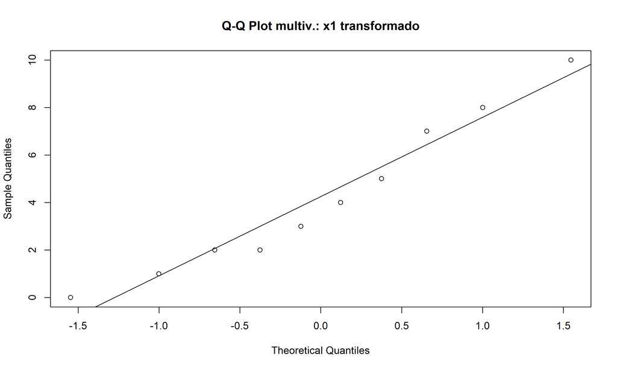

```r
# Q-Q plots dos dados transformados conjuntamente
dados_trans <- bcPower(cbind(x1, x2), bc_multi$roundlam)
qqnorm(dados_trans[,1], main = "Q-Q Plot multiv.: x1 transformado"); qqline(dados_trans[,1])
```

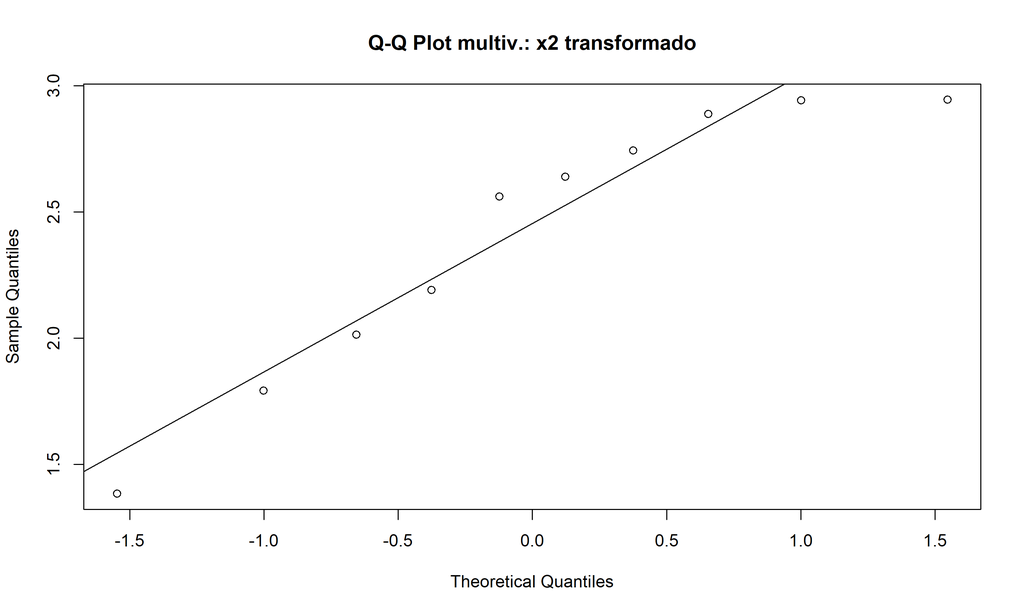

```r
qqnorm(dados_trans[,2], main = "Q-Q Plot multiv.: x2 transformado"); qqline(dados_trans[,2])
```

## Exercise 4.31

Examine the marginal normality of the observations on variables $X_1, X_2, \ldots, X_5$ for the multiple-sclerosis data in Table 1.6. Treat the non-multiple-sclerosis and multiple-sclerosis groups separately. Use whatever methodology, including transformations, you feel is appropriate.

## Exercise 4.32

Examine the marginal normality of the observations on variables $X_1, X_2, \ldots, X_6$ for the radiotherapy data in Table 1.7. Use whatever methodology, including transformations, you feel is appropriate.

## Exercise 4.33

Examine the marginal and bivariate normality of the observations on variables $X_1, X_2, X_3$, and $X_4$ for the data in Table 4.3.

## Exercise 4.34

Examine the data on bone mineral content in Table 1.8 for marginal and bivariate normality.

## Exercise 4.35

Examine the data on paper-quality measurements in Table 1.2 for marginal and multivariate normality.

## Exercise 4.36

Examine the data on women’s national track records in Table 1.9 for marginal and multivariate normality.

## Exercise 4.37

Refer to Exercise 1.18. Convert the women’s track records in Table 1.9 to speeds measured in meters per second. Examine the data on speeds for marginal and multivariate normality.

## Exercise 4.38

Examine the data on bulls in Table 1.10 for marginal and multivariate normality. Consider only the variables YrHgt, FtFrBody, PrctFFB, BkFat, SaleHt, and SaleWt.

## Exercise 4.39

The data in Table 4.6 (see the psychological profile data: `www.prenhall.com/statistics`) consist of 130 observations generated by scores on a psychological test administered to Peruvian teenagers (ages 15, 16, and 17). For each of these teenagers the gender (male $= 1$, female $= 2$) and socioeconomic status (low $= 1$, medium $= 2$) were also recorded. The scores were accumulated into five subscale scores labeled *independence* (indep), *support* (supp), *benevolence* (benev), *conformity* (conform), and *leadership* (leader).

1. Examine each of the variables independence, support, benevolence, conformity, and leadership for marginal normality.
2. Using all five variables, check for multivariate normality.
3. Refer to part (a). For those variables that are nonnormal, determine the transformation that makes them more nearly normal.

## Exercise 4.40

Consider the data on national parks in Exercise 1.27.

1. Comment on any possible outliers in a scatter plot of the original variables.
2. Determine the power transformation $\hat{\lambda}_1$ that makes the $x_1$ values approximately normal. Construct a $Q$–$Q$ plot of the transformed observations.
3. Determine the power transformation $\hat{\lambda}_2$ that makes the $x_2$ values approximately normal. Construct a $Q$–$Q$ plot of the transformed observations.
4. Determine the power transformation for approximate bivariate normality using (4-40).

## Exercise 4.41

Consider the data on snow removal in Exercise 3.20.

1. Comment on any possible outliers in a scatter plot of the original variables.
2. Determine the power transformation $\hat{\lambda}_1$ that makes the $x_1$ values approximately normal. Construct a $Q$–$Q$ plot of the transformed observations.
3. Determine the power transformation $\hat{\lambda}_2$ that makes the $x_2$ values approximately normal. Construct a $Q$–$Q$ plot of the transformed observations.
4. Determine the power transformation for approximate bivariate normality using (4-40).